# Autoencoders, Anomaly Detection with Unbalanced Data

## Get Data

Use Kaggle’s credit card fraud dataset:

```r
library(tidyverse)
# download from https://www.kaggle.com/dalpozz/creditcardfraud
creditcard <- file.choose()
```

The dataset gives > 280,000 instances of credit card use and for each transaction we know whether it was fraudulent or not.

Datasets like this needs special treatment when performing machine learning because they are severely unbalanced: in this case, only 0.17% of all transactions are fraudulent.

While we could try to work with classifiers, like random forests or support vector machines, by applying over- or under-sampling techniques, we can alternatively try to find anomalies in the data (assuming we expect our fraud cases to be anomalies within the whole dataset).

When dealing with such a severe unbalance of response labels we need to be careful when measuring model performance. Because there are only a handful of fraudulent instances, a model that predicts everything as non-fraud will already achieve a > 99% accuracy. But despite its high accuracy, such a model won’t necessarily help us find fraudulent cases - the proverbial “needle-in-a-haystack” - that we actually want to find.

Below, autoencoders and anomaly detection are used to pre-train a classification model and how you can measure model performance on unbalanced data.

## Exploring the data

The dataset contains numerical input variables V1 to V28, which are the result of a PCA transformation of the original features (which could not be provided due to confidentiality issues).

The response variable Class tell us whether a transaction was fraudulent (value = 1) or not (value = 0).

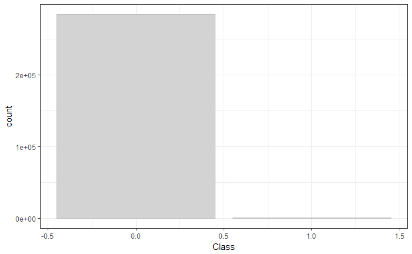

```r
creditcard %>% ggplot(aes(x = Class)) + geom_bar(color = "grey", fill = "lightgrey") +  theme_bw()
```

There are two additional features, Time (time in seconds between each transaction and the first transaction) and Amount (how much money was transferred in this transaction).

Because Time only tells us the order in which transactions have been done, it doesn’t actually tell us anything about the actual times (i.e. time of day) of the transaction. Therefore, I am normalizing them by day and bin them into four groups according to time of day.

```r
summary(creditcard$Time)
```

```
   Min. 1st Qu.  Median    Mean 3rd Qu.    Max.
      0   54200   84690   94810  139300  172800
```

```r
# separate transactions by day
creditcard$day <- ifelse(creditcard$Time > 3600 * 24, "day2", "day1")
# make transaction relative to day
creditcard$Time_day <- ifelse(creditcard$day == "day2", creditcard$Time - 86400, creditcard$Time)
summary(creditcard[creditcard$day == "day1", ]$Time_day)
```

```
   Min. 1st Qu.  Median    Mean 3rd Qu.    Max.
      0   38430   54690   52950   70980   86400
```

```r
summary(creditcard[creditcard$day == "day2", ]$Time_day)
```

```
   Min. 1st Qu.  Median    Mean 3rd Qu.    Max.
      1   37840   53420   51710   68180   86390
```

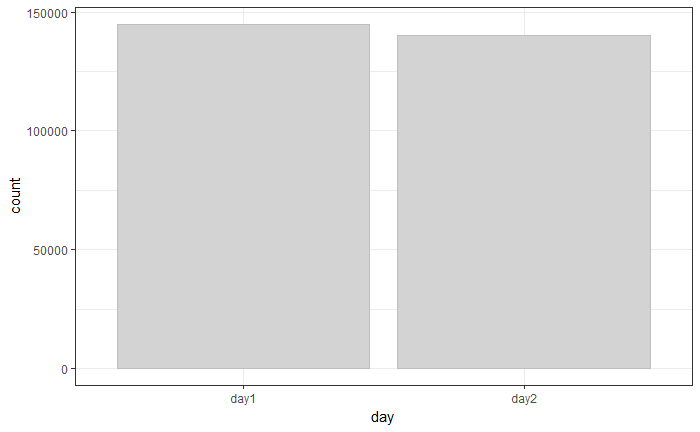

```r
# bin transactions according to time of day
creditcard$Time <- as.factor(ifelse(creditcard$Time_day <= 38138, "gr1", # mean 1st Qu.
                ifelse(creditcard$Time_day <= 52327, "gr2", # mean mean
                       ifelse(creditcard$Time_day <= 69580, "gr3", # mean 3rd Qu
                              "gr4"))))
creditcard %>% ggplot(aes(x = day)) + geom_bar(color = "grey", fill = "lightgrey") + theme_bw()
```

We can see now that the transactions in this dataset have all been recorded on two consecutive days and there are roughly the same number of transactions on these two days.

Now, I remove the columns I used to create the Time bins.

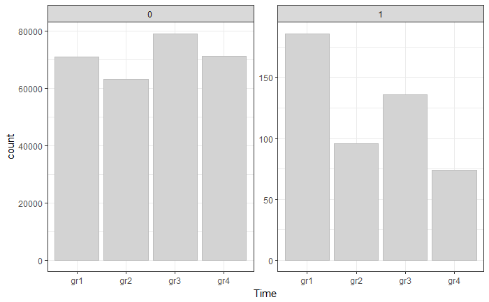

```r
creditcard <- select(creditcard, -Time_day, -day)
# convert class variable to factor
creditcard$Class <- factor(creditcard$Class)
creditcard %>%  ggplot(aes(x = Time)) + geom_bar(color = "grey", fill = "lightgrey") +
    theme_bw() + facet_wrap( ~ Class, scales = "free", ncol = 2)
```

I also want to look at the distribution of the amounts of money that were transferred:

```r
summary(creditcard[creditcard$Class == "0", ]$Amount)
```

```
    Min.  1st Qu.   Median     Mean  3rd Qu.     Max.
    0.00     5.65    22.00    88.29    77.05 25690.00
```

```r
summary(creditcard[creditcard$Class == "1", ]$Amount)
```

```
   Min. 1st Qu.  Median    Mean 3rd Qu.    Max.
   0.00    1.00    9.25  122.20  105.90 2126.00
```

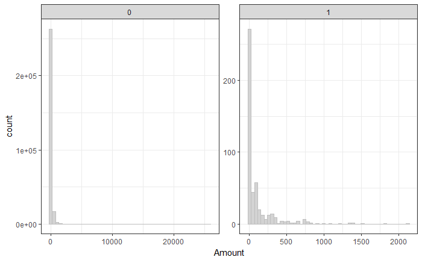

```r
creditcard %>% ggplot(aes(x = Amount)) + geom_histogram(color = "grey", fill = "lightgrey", bins = 50) +
     theme_bw() + facet_wrap( ~ Class, scales = "free", ncol = 2)
```

Interestingly, fraudulent credit card transactions had a higher mean amount of money that was transferred but the maximum amount was much lower compared to regular transactions.

## Modeling

For modeling, I am using R’s H2O implementation with the h2o package. For more details and other examples, see my posts on my machine learning webinar, on building neural nets with h2o and on performing grid search for hyperparameter tuning.

```r
creditcard_hf <- as.h2o(creditcard)
```

Split the dataset into training and test sets. Because I want to check how a pre-trained model with perform, I am splitting my data into two separate training sets and one independent test set for final model comparison.

```r
splits <- h2o.splitFrame(creditcard_hf, ratios = c(0.4, 0.4), seed = 42)
train_unsupervised  <- splits[[1]]
train_supervised  <- splits[[2]]
test <- splits[[3]]
response <- "Class"
features <- setdiff(colnames(train_unsupervised), response)
```

## Autoencoders

First, I am training the unsupervised neural network model using deep learning autoencoders. With h2o, we can simply set autoencoder = TRUE.

Here, I am applying a technique called “bottleneck” training, where the hidden layer in the middle is very small. This means that my model will have to reduce the dimensionality of the input data (in this case, down to 2 nodes/dimensions).

The autoencoder model will then learn the patterns of the input data irrespective of given class labels. Here, it will learn, which credit card transactions are similar and which transactions are outliers or anomalies. We need to keep in mind though, that autoencoder models will be sensitive to outliers in our data, which might throw off otherwise typical patterns.

```r
model_nn <- h2o.deeplearning(x = features,
                             training_frame = train_unsupervised,
                             model_id = "model_nn",
                             autoencoder = TRUE,
                             reproducible = TRUE, #slow - turn off for real problems
                             ignore_const_cols = FALSE,
                             seed = 42,
                             hidden = c(10, 2, 10),
                             epochs = 100,
                             activation = "Tanh")
```

Because training can take a while, I am saving the model:

```r
h2o.saveModel(model_nn, path="model_nn", force = TRUE)
```

```r
model_nn
```

```
Model Details:
==============

H2OAutoEncoderModel: deeplearning
Model ID:  model_nn
Status of Neuron Layers: auto-encoder, gaussian distribution, Quadratic loss, 776 weights/biases, 16.2 KB, 3,078,999 training samples, mini-batch size 1
  layer units  type dropout       l1       l2 mean_rate rate_rms momentum mean_weight weight_rms mean_bias bias_rms
1     1    34 Input  0.00 %
2     2    10  Tanh  0.00 % 0.000000 0.000000  0.828081 0.245066 0.000000   -0.056359   0.803946 -0.107397 1.518055
3     3     2  Tanh  0.00 % 0.000000 0.000000  0.063982 0.108885 0.000000   -0.082333   0.364984  0.247254 0.104044
4     4    10  Tanh  0.00 % 0.000000 0.000000  0.159982 0.176786 0.000000    0.201821   1.226047  0.080519 0.669157
5     5    34  Tanh         0.000000 0.000000  0.363700 0.415370 0.000000    0.011648   0.680734  0.048081 0.724575


H2OAutoEncoderMetrics: deeplearning
** Reported on training data. **

Training Set Metrics:
=====================

MSE: (Extract with `h2o.mse`) 0.001448197
RMSE: (Extract with `h2o.rmse`) 0.03805519
```

```r
#Convert to autoencoded representation
test_autoenc <- h2o.predict(model_nn, test)
```

## Dimensionality reduction with hidden layers

Because I had used a bottleneck model with two nodes in the hidden layer in the middle, we can use this dimensionality reduction to explore our feature space (similar to what to we could do with a principal component analysis). We can extract this hidden feature with the h2o.deepfeatures() function and plot it to show the reduced representation of the input data.

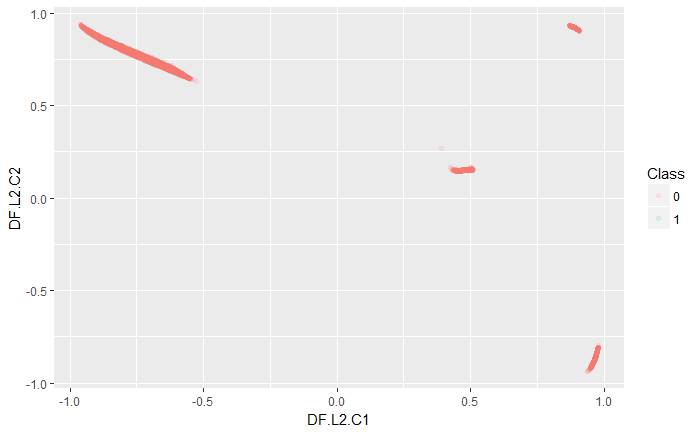

```r
train_features <- h2o.deepfeatures(model_nn, train_unsupervised, layer = 2) %>%
  as.data.frame() %>%
  mutate(Class = as.vector(train_unsupervised[, 31]))
ggplot(train_features, aes(x = DF.L2.C1, y = DF.L2.C2, color = Class)) + geom_point(alpha = 0.1)
```

Here, we do not see a cluster of fraudulent transactions that is distinct from non-fraud instances, so dimensionality reduction with our autoencoder model alone is not sufficient to identify fraud in this dataset.

But we could use the reduced dimensionality representation of one of the hidden layers as features for model training. An example would be to use the 10 features from the first or third hidden layer:

```r
# let's take the third hidden layer
train_features <- h2o.deepfeatures(model_nn, train_unsupervised, layer = 3) %>% as.data.frame() %>%
  mutate(Class = as.factor(as.vector(train_unsupervised[, 31]))) %>% as.h2o()
features_dim <- setdiff(colnames(train_features), response)
model_nn_dim <- h2o.deeplearning(y = response,
                               x = features_dim,
                               training_frame = train_features,
                               reproducible = TRUE, #slow - turn off for real problems
                               balance_classes = TRUE,
                               ignore_const_cols = FALSE,
                               seed = 42,
                               hidden = c(10, 2, 10),
                               epochs = 100,
                               activation = "Tanh")
```

```r
h2o.saveModel(model_nn_dim, path="model_nn_dim", force = TRUE)
```

```r
model_nn_dim
```

```
Model Details:
==============

H2OBinomialModel: deeplearning
Model ID:  DeepLearning_model_R_1504628086320_1
Status of Neuron Layers: predicting Class, 2-class classification, bernoulli distribution, CrossEntropy loss, 184 weights/biases, 7.2 KB, 4,553,360 training samples, mini-batch size 1
  layer units    type dropout       l1       l2 mean_rate rate_rms momentum mean_weight weight_rms mean_bias bias_rms
1     1    10   Input  0.00 %
2     2    10    Tanh  0.00 % 0.000000 0.000000  0.012031 0.021979 0.000000   -0.219937   3.051839  0.781291 1.703607
3     3     2    Tanh  0.00 % 0.000000 0.000000  0.000312 0.000134 0.000000   -0.301697   1.402969 -2.696903 0.403040
4     4    10    Tanh  0.00 % 0.000000 0.000000  0.225957 0.111415 0.000000    0.128050   1.998901 -0.361804 1.089969
5     5     2 Softmax         0.000000 0.000000  0.135322 0.065438 0.000000    0.563946   1.052547  0.000000 0.131943


H2OBinomialMetrics: deeplearning
** Reported on training data. **
** Metrics reported on temporary training frame with 9974 samples **

MSE:  0.4836446
RMSE:  0.6954456
LogLoss:  2.724373
Mean Per-Class Error:  0.3601753
AUC:  0.7364843
Gini:  0.4729686

Confusion Matrix (vertical: actual; across: predicted) for F1-optimal threshold:
          0    1    Error        Rate
0      1564 3468 0.689189  =3468/5032
1       154 4788 0.031161   =154/4942
Totals 1718 8256 0.363144  =3622/9974

Maximum Metrics: Maximum metrics at their respective thresholds
                        metric threshold    value idx
1                       max f1  0.001152 0.725564 334
2                       max f2  0.000736 0.857544 355
3                 max f0point5  0.002435 0.664222 263
4                 max accuracy  0.002435 0.673852 263
5                max precision  0.161664 1.000000   0
6                   max recall  0.000500 1.000000 368
7              max specificity  0.161664 1.000000   0
8             max absolute_mcc  0.001152 0.370288 334
9   max min_per_class_accuracy  0.002435 0.572536 263
10 max mean_per_class_accuracy  0.002435 0.674775 263

Gains/Lift Table: Extract with `h2o.gainsLift(<model>, <data>)` or `h2o.gainsLift(<model>, valid=<T/F>, xval=<T/F>)`
```

For measuring model performance on test data, we need to convert the test data to the same reduced dimensions as the trainings data:

```r
test_dim <- h2o.deepfeatures(model_nn, test, layer = 3)
h2o.predict(model_nn_dim, test_dim) %>% as.data.frame() %>% mutate(actual = as.vector(test[, 31])) %>%
  group_by(actual, predict) %>% summarise(n = n()) %>% mutate(freq = n / sum(n))
```

| actual | predict | n | freq |
| --- | --- | --- | --- |
| 0 | 0 | 17616 | 0.31106088 |
| 0 | 1 | 39016 | 0.68893912 |
| 1 | 0 | 2 | 0.02173913 |
| 1 | 1 | 90 | 0.97826087 |

## Anomaly detection

We can also ask which instances were considered outliers or anomalies within our test data, using the h2o.anomaly() function. Based on the autoencoder model that was trained before, the input data will be reconstructed and for each instance, the mean squared error (MSE) between actual value and reconstruction is calculated.

I am also calculating the mean MSE for both class labels.

```r
anomaly <- h2o.anomaly(model_nn, test) %>% as.data.frame() %>% tibble::rownames_to_column() %>% mutate(Class = as.vector(test[, 31]))
mean_mse <- anomaly %>% group_by(Class) %>% summarise(mean = mean(Reconstruction.MSE))
```

This, we can now plot:

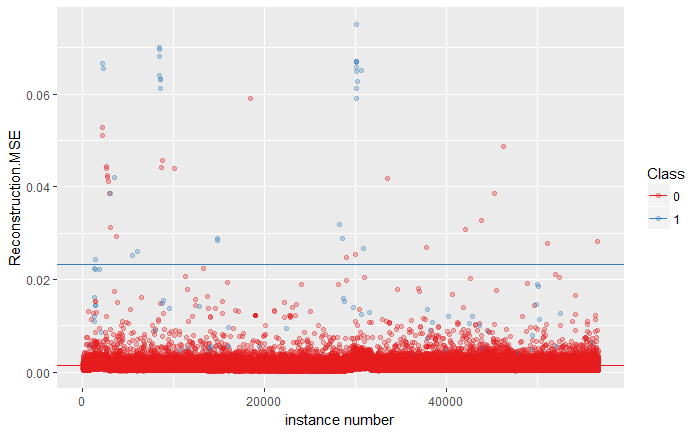

```r
ggplot(anomaly, aes(x = as.numeric(rowname), y = Reconstruction.MSE, color = as.factor(Class))) +
  geom_point(alpha = 0.3) + geom_hline(data = mean_mse, aes(yintercept = mean, color = Class)) +
  scale_color_brewer(palette = "Set1") + labs(x = "instance number", color = "Class")
```

As we can see in the plot, there is no perfect classification into fraud and non-fraud cases but the mean MSE is definitely higher for fraudulent transactions than for regular ones.

We can now identify outlier instances by applying an MSE threshold for what we consider outliers. We could e.g. say that we consider every instance with an MSE > 0.02 (chosen according to the plot above) to be an anomaly/outlier.

```r
anomaly <- anomaly %>% mutate(outlier = ifelse(Reconstruction.MSE > 0.02, "outlier", "no_outlier"))
anomaly %>% group_by(Class, outlier) %>% summarise(n = n()) %>% mutate(freq = n / sum(n))
```

| Class | outlier | n | freq |
| --- | --- | --- | --- |
| 0 | no_outlier | 56602 | 0.9994702642 |
| 0 | outlier | 30 | 0.0005297358 |
| 1 | no_outlier | 60 | 0.6521739130 |
| 1 | outlier | 32 | 0.3478260870 |

As we can see, outlier detection is not sufficient to correctly classify fraudulent credit card transactions either (at least not with this dataset).

## Pre-trained supervised model

We can now try using the autoencoder model as a pre-training input for a supervised model. Here, I am again using a neural network. This model will now use the weights from the autoencoder for model fitting.

```r
model_nn_2 <- h2o.deeplearning(y = response,
                               x = features,
                               training_frame = train_supervised,
                               pretrained_autoencoder  = "model_nn",
                               reproducible = TRUE, #slow - turn off for real problems
                               balance_classes = TRUE,
                               ignore_const_cols = FALSE,
                               seed = 42,
                               hidden = c(10, 2, 10),
                               epochs = 100,
                               activation = "Tanh")
```

```r
h2o.saveModel(model_nn_2, path="model_nn_2", force = TRUE)
```

```r
model_nn_2
```

```
Model Details:
==============

H2OBinomialModel: deeplearning
Model ID:  DeepLearning_model_R_1504628086320_23
Status of Neuron Layers: predicting Class, 2-class classification, bernoulli distribution, CrossEntropy loss, 424 weights/biases, 11.8 KB, 13,889,883 training samples, mini-batch size 1
  layer units    type dropout       l1       l2 mean_rate rate_rms momentum mean_weight weight_rms mean_bias bias_rms
1     1    34   Input  0.00 %
2     2    10    Tanh  0.00 % 0.000000 0.000000  0.793635 0.332953 0.000000   -0.012780   1.356666 -0.108627 2.400342
3     3     2    Tanh  0.00 % 0.000000 0.000000  0.851693 0.175319 0.000000   -0.035225   0.993426 -0.266087 1.856786
4     4    10    Tanh  0.00 % 0.000000 0.000000  0.998776 0.009405 0.000000    0.815884   2.005008  0.784216 0.980405
5     5     2 Softmax         0.000000 0.000000  0.626231 0.398185 0.000000   -3.064094   5.676661  8.691606 7.213642


H2OBinomialMetrics: deeplearning
** Reported on training data. **
** Metrics reported on temporary training frame with 9973 samples **

MSE:  0.0004172918
RMSE:  0.02042772
LogLoss:  0.003498283
Mean Per-Class Error:  0.0003986446
AUC:  0.9998327
Gini:  0.9996655

Confusion Matrix (vertical: actual; across: predicted) for F1-optimal threshold:
          0    1    Error     Rate
0      5013    4 0.000797  =4/5017
1         0 4956 0.000000  =0/4956
Totals 5013 4960 0.000401  =4/9973

Maximum Metrics: Maximum metrics at their respective thresholds
                        metric threshold    value idx
1                       max f1  0.975715 0.999597  82
2                       max f2  0.975715 0.999839  82
3                 max f0point5  0.975715 0.999355  82
4                 max accuracy  0.975715 0.999599  82
5                max precision  0.992402 0.999791  71
6                   max recall  0.975715 1.000000  82
7              max specificity  0.997705 0.999801   0
8             max absolute_mcc  0.975715 0.999198  82
9   max min_per_class_accuracy  0.975715 0.999203  82
10 max mean_per_class_accuracy  0.975715 0.999601  82

Gains/Lift Table: Extract with `h2o.gainsLift(<model>, <data>)` or `h2o.gainsLift(<model>, valid=<T/F>, xval=<T/F>)`
```

```r
pred <- as.data.frame(h2o.predict(object = model_nn_2, newdata = test)) %>%
  mutate(actual = as.vector(test[, 31]))
pred %>% group_by(actual, predict) %>% summarise(n = n()) %>% mutate(freq = n / sum(n))
```

| actual | predict | n | freq |
| --- | --- | --- | --- |
| 0 | 0 | 56594 | 0.9993290013 |
| 0 | 1 | 38 | 0.0006709987 |
| 1 | 0 | 16 | 0.1739130435 |
| 1 | 1 | 76 | 0.8260869565 |

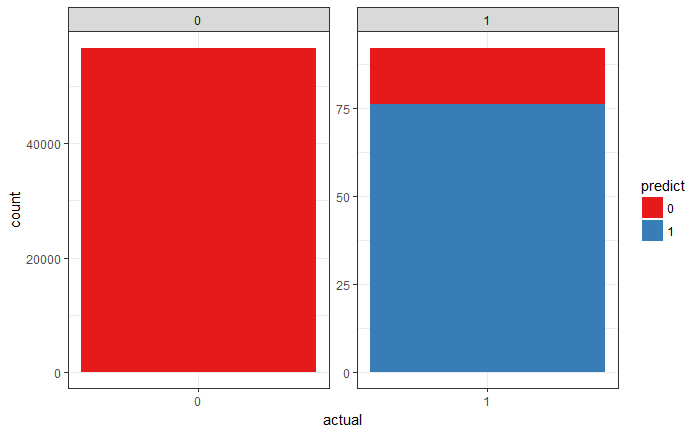

```r
pred %>% ggplot(aes(x = actual, fill = predict)) + geom_bar() + theme_bw() +
    scale_fill_brewer(palette = "Set1") + facet_wrap( ~ actual, scales = "free", ncol = 2)
```

Now, this looks much better! We did miss 17% of the fraud cases but we also did not mis-classify too many of the non-fraud cases.

In real-life, we would now spend some more time trying to improve the model by e.g. performing grid search for hyperparameter tuning, going back to the original features (which we did not have here) and trying different engineered features and/or trying different algorithms. But here, I will leave it at that.

## Measuring model performance on highly unbalanced data

Because of the severe bias towards non-fraud cases, we can not use performance measures like accuracy or area under the curve (AUC), as they would give overly optimistic results based on the high percentage of correct classifications of the majority class.

An alternative to AUC is to use the precision-recall curve or the sensitivity (recall)-specificity curve. To calculate and plot these metrics, we can use the ROCR package. There are different ways to calculate the area under a curve (see the PRROC package for details) but I am going to use a simple function that calculates the area between every consecutive points-pair of x (i.e. x1 - x0, x2 - x1, etc.) under the corresponding values of y.

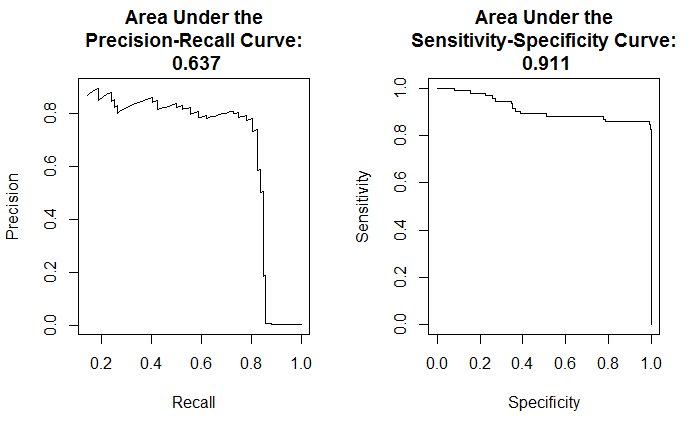

```r
library(ROCR)
# http://stackoverflow.com/questions/24563061/computing-integral-of-a-line-plot-in-r
line_integral <- function(x, y) {
  dx <- diff(x)
  end <- length(y)
  my <- (y[1:(end - 1)] + y[2:end]) / 2
  sum(dx * my)
}
prediction_obj <- prediction(pred$p1, pred$actual)
par(mfrow = c(1, 2))
par(mar = c(5.1,4.1,4.1,2.1))
# precision-recall curve
perf1 <- performance(prediction_obj, measure = "prec", x.measure = "rec")
x <- perf1@x.values[[1]]
y <- perf1@y.values[[1]]
y[1] <- 0
plot(perf1, main = paste("Area Under the\nPrecision-Recall Curve:\n", round(abs(line_integral(x,y)), digits = 3)))
# sensitivity-specificity curve
perf2 <- performance(prediction_obj, measure = "sens", x.measure = "spec")
x <- perf2@x.values[[1]]
y <- perf2@y.values[[1]]
y[1] <- 0
plot(perf2, main = paste("Area Under the\nSensitivity-Specificity Curve:\n", round(abs(line_integral(x,y)), digits = 3)))
```

Precision is the proportion of test cases predicted to be fraud that were indeed fraudulent (i.e. the true positive predictions), while recall or sensitivity is the proportion of fraud cases that were identified as fraud. And specificity is the proportion of non-fraud cases that are identified as non-fraud.

The precision-recall curve tells us the relationship between correct fraud predictions and the proportion of fraud cases that were detected (e.g. if all or most fraud cases were identified, we also have many non-fraud cases predicted as fraud and vice versa). The sensitivity-specificity curve thus tell us the relationship between correctly identified classes of both labels (e.g. if we have 100% correctly classified fraud cases, we will have no correctly classified non-fraud cases and vice versa).

We can also look at this a little bit differently, by manually going through different prediction thresholds and calculating how many cases were correctly classified in the two classes:

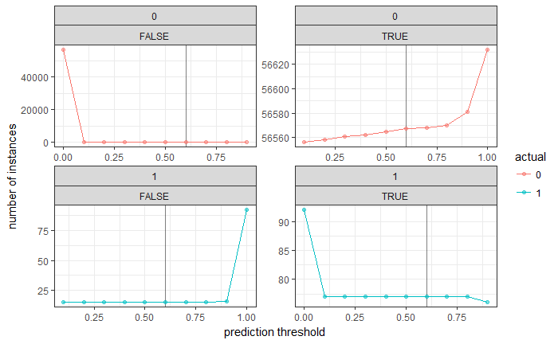

```r
thresholds <- seq(from = 0, to = 1, by = 0.1)
pred_thresholds <- data.frame(actual = pred$actual)
for (threshold in thresholds) {

  prediction <- ifelse(pred$p1 > threshold, 1, 0)
  prediction_true <- ifelse(pred_thresholds$actual == prediction, TRUE, FALSE)
  pred_thresholds <- cbind(pred_thresholds, prediction_true)
}
colnames(pred_thresholds)[-1] <- thresholds
pred_thresholds %>%
  gather(x, y, 2:ncol(pred_thresholds)) %>%
  group_by(actual, x, y) %>%
  summarise(n = n()) %>%
  ggplot(aes(x = as.numeric(x), y = n, color = actual)) +
    geom_vline(xintercept = 0.6, alpha = 0.5) +
    geom_line() +
    geom_point(alpha = 0.5) +
    theme_bw() +
    facet_wrap(actual ~ y, scales = "free", ncol = 2) +
    labs(x = "prediction threshold",
         y = "number of instances")
```

This plot tells us that we can increase the number of correctly classified non-fraud cases without loosing correctly classified fraud cases when we increase the prediction threshold from the default 0.5 to 0.6:

```r
pred %>% mutate(predict = ifelse(pred$p1 > 0.6, 1, 0)) %>% group_by(actual, predict) %>% summarise(n = n()) %>% mutate(freq = n / sum(n))
```

| actual | predict | n | freq |
| --- | --- | --- | --- |
| 0 | 0 | 56567 | 0.998852239 |
| 0 | 1 | 65 | 0.001147761 |
| 1 | 0 | 15 | 0.163043478 |
| 1 | 1 | 77 | 0.836956522 |

Our final model now correctly identified 83% of fraud cases and almost 100% of non-fraud cases.

Reference: https://shiring.github.io/machine_learning/2017/05/01/fraud